# PML HumanActivityRecognition

#### Getting the data

```r
if (!file.exists("data")) dir.create("data")

trainingURL = "https://d396qusza40orc.cloudfront.net/predmachlearn/pml-training.csv"
testingURL = "https://d396qusza40orc.cloudfront.net/predmachlearn/pml-testing.csv"

download.file(trainingURL, "./data/pml-training.csv", method="curl")
download.file(testingURL, "./data/pml-testing.csv", method="curl")
```

```r
training.raw <- read.csv("./data/pml-training.csv", header=TRUE, na.strings=c(""," ","NA"))
testing.raw <- read.csv("./data/pml-testing.csv", header=TRUE, na.strings=c(""," ","NA"))
```

#### Cleaning the data

The raw training data consists of 19622 observations of 160 variables. Inspection of the data (e.g., head(training.raw), summary(training.raw)) shows initial columns with name and timestamps that can be removed as well as many columns with missing values. Removing these leaves 53 variables.

```r
dim(training.raw)
```

```
## [1] 19622   160
```

```r
dim(testing.raw)
```

```
## [1]  20 160
```

```r
# remove initial columns with name and timestamp information
training <- training.raw[,-c(1:7)]
testing <- testing.raw[,-c(1:7)]

# remove NAs and missing values
training <- training[,colSums(is.na(training))==0]
testing <- testing[,colSums(is.na(testing))==0]
dim(training)
```

```
## [1] 19622    53
```

#### Cross Validation

Use cross validataion to estimate test set accuracy with the training set. Split the training set into training and testing subsets.Build a model on the training subset and evaluate it on the testing subset.

```r
require(caret)
inTrain <- createDataPartition(y=training$classe, p=0.60, list=FALSE,)
subTraining <- training[inTrain,]
subTesting <- training[-inTrain,]
dim(subTraining); dim(subTesting)
```

```
## [1] 11776    53
```

```
## [1] 7846   53
```

#### Fit a model

Build a model on the training subset. Use random forest model because of its good accuracy, although it can be slow. Use cross validation to build a robust model, with a low number of folds to keep the runtime in check.

```r
set.seed(32323)
train_control <- trainControl(method="cv", number=3)
model.rf <- train(classe ~., data=subTraining, trControl=train_control,  method="rf", tuneLength=1)
model.rf
```

```
## Random Forest
##
## 11776 samples
##    52 predictor
##     5 classes: 'A', 'B', 'C', 'D', 'E'
##
## No pre-processing
## Resampling: Cross-Validated (3 fold)
##
## Summary of sample sizes: 7850, 7851, 7851
##
## Resampling results
##
##   Accuracy   Kappa      Accuracy SD  Kappa SD
##   0.9881115  0.9849592  0.001911288  0.002419642
##
## Tuning parameter 'mtry' was held constant at a value of 7
##
```

#### Expected Out of Sample Error

The validation set (the subTesting set) was not used for training the model, so we can use it to estimate performance on unseen data. The accuracy of our model is high at 99%, so the expected out of sample error rate is a low .007, so there is no need to refine this model further.

```r
predict.rf <- predict(model.rf, subTesting)
conf.results <- confusionMatrix(predict.rf,subTesting$classe)
conf.results
```

```
## Confusion Matrix and Statistics
##
##           Reference
## Prediction    A    B    C    D    E
##          A 2228   11    0    0    0
##          B    0 1504   10    0    0
##          C    0    3 1356   22    0
##          D    1    0    2 1264    0
##          E    3    0    0    0 1442
##
## Overall Statistics
##
##                Accuracy : 0.9934
##                  95% CI : (0.9913, 0.995)
##     No Information Rate : 0.2845
##     P-Value [Acc > NIR] : < 2.2e-16
##
##                   Kappa : 0.9916
##  Mcnemar's Test P-Value : NA
##
## Statistics by Class:
##
##                      Class: A Class: B Class: C Class: D Class: E
## Sensitivity            0.9982   0.9908   0.9912   0.9829   1.0000
## Specificity            0.9980   0.9984   0.9961   0.9995   0.9995
## Pos Pred Value         0.9951   0.9934   0.9819   0.9976   0.9979
## Neg Pred Value         0.9993   0.9978   0.9981   0.9967   1.0000
## Prevalence             0.2845   0.1935   0.1744   0.1639   0.1838
## Detection Rate         0.2840   0.1917   0.1728   0.1611   0.1838
## Detection Prevalence   0.2854   0.1930   0.1760   0.1615   0.1842
## Balanced Accuracy      0.9981   0.9946   0.9937   0.9912   0.9998
```

#### Predicting New Values

Use the model to predict the unseen test set. The predictions are correct on the 20 test cases, as expected given the model accuracy and low out of sample error.

```r
test.results <- predict(model.rf, testing)
test.results
```

```
##  [1] B A B A A E D B A A B C B A E E A B B B
## Levels: A B C D E
```

This plot shows the relative importance of the top 30 parameters in the model.

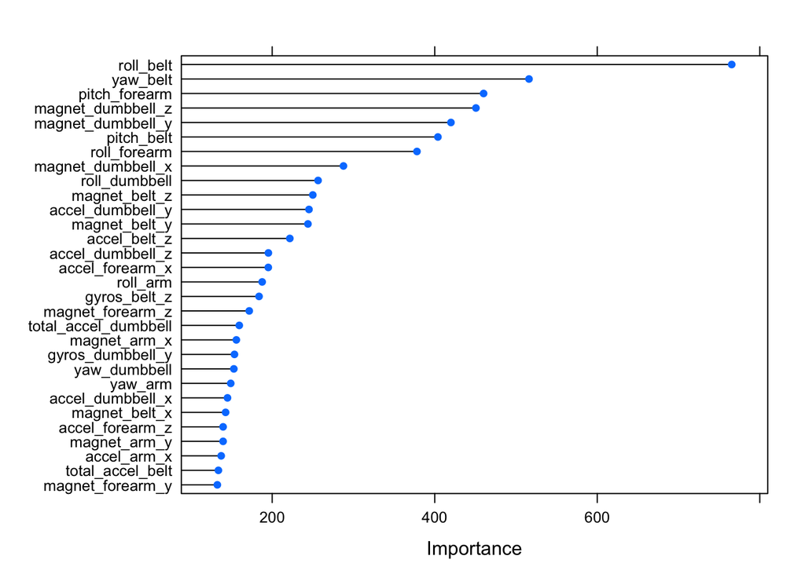

```r
plot(varImp(model.rf, scale=FALSE), top=30)
```

##### References

Ugulino, W.; Cardador, D.; Vega, K.; Velloso, E.; Milidiu, R.; Fuks, H. Wearable Computing: Accelerometers’ Data Classification of Body Postures and Movements. Proceedings of 21st Brazilian Symposium on Artificial Intelligence. Advances in Artificial Intelligence - SBIA 2012. In: Lecture Notes in Computer Science. , pp. 52-61. Curitiba, PR: Springer Berlin / Heidelberg, 2012. ISBN 978-3-642-34458-9. DOI: 10.1007/978-3-642-34459-6_6. http://groupware.les.inf.puc-rio.br/har.